# Report for Job [KEY:SNP_microRNA__Linear__Yes]

WGIA

2024-08-13 19:53:25

**You can bookmark this page to access the results later, or [download the report](http://gpu.zjwm.cc:88/wgia/public/job/SNP_microRNA__Linear__Yes/report.html) locally.**

*Results will be stored for 30 days.*

> WGIA is an open-access web application designed for genome-wide interaction analysis. Leveraging GPU parallel technologies, it significantly enhances computational efficiency. You can upload the SNP, DNA methylation, gene expression, or other biological data, and WGIA generates a comprehensive report within a short timeframe.

# 1. Datasets information

## 1.1 marker information

**There are total 999 Single Neucleotide Polymorphism (SNP) and 100 microRNA (microRNA) used for interaction analysis.**

- In order to provide the fullest results as possible, WGIA provided interaction for all the SNP and microRNA uploaded, without quality control for the data.
- Note: If needed, some basic information about SNP and microRNA can be used to perform quality control before uploaded the datasets, such as the missing rate.

## 1.2 sample information

**There are total of 50 samples used for interaction calculation.** **Note: There are 3 other sample information be used as covariates, respectively are v1, v2, v3..**

# 2. Interaction analysis results

## 2.1 Regulatory effect (regression coefficient) distribution

**WGIA performed a total of 99,900 calculations between 999 SNP and 100 microRNA for this job, encompassing linear regression among all possible SNP-microRNA pairs. v1, v2, v3 were considered as covariates in the regression model. The results are displayed below.**

> **eQTL identification (SNP×microRNA):** Expression Quantitative Trait Loci (eQTL) Identification (SNP vs. microRNA) identifies SNPs that affect microRNA (microRNA) expression levels. MicroRNAs play crucial roles in post-transcriptional regulation of gene expression, and this analysis helps to understand how genetic variations can impact these regulatory processes.  
> **Linear regression** is a statistical method used to identify the relationship between two variables. For eQTL identification (SNP×microRNA), the linear regression model typically includes the genetic marker information of SNP as predictor variables and the quantitative trait measurements of microRNA as the response variable. In the linear regression analysis, considering covariates helps control for confounding factors, improving the accuracy and interpretability of the association between two markers.

- These results can be downloaded here LR_distribution.txt.

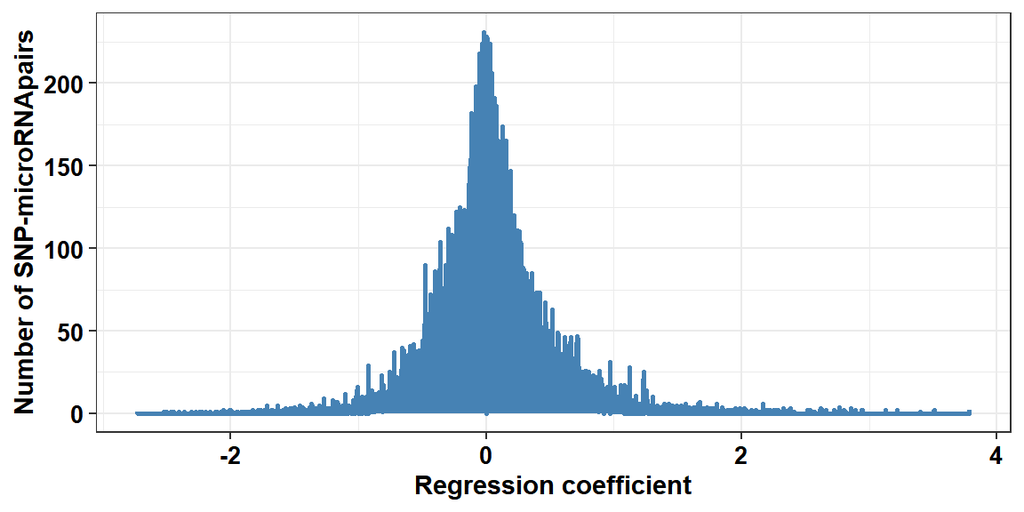

- A more rough distribution of intervals is as follows:

|  | lower_interval | upper_interval | frequency |
| --- | --- | --- | --- |
| 1 | -5 | -2 | 25 |
| 2 | -2 | -1 | 921 |
| 3 | -1 | -0.9 | 406 |
| 4 | -0.9 | -0.8 | 621 |
| 5 | -0.8 | -0.7 | 966 |
| 6 | -0.7 | -0.6 | 1461 |
| 7 | -0.6 | -0.5 | 1977 |
| 8 | -0.5 | -0.3999999999999999 | 3346 |
| 9 | -0.3999999999999999 | -0.2999999999999999 | 4839 |
| 10 | -0.2999999999999999 | -0.2 | 7073 |

[output cut: 14 more lines]

## 2.2 Regulatory effect (regression coefficient) distribution metrics

**Some basic information about the distribution is provided in the table below, including mean value, variance, standard deviation, skewness, kurtosis, median_value, lower quartile, upper quartile, interquartile range.**

- **Mean value**: The average value of the data set.
- **Variance**: A measure of how much the data points differ from the mean.
- **Standard deviation**: The square root of the variance, indicating the spread of the data.
- **Skewness**: A measure of the asymmetry of the data distribution.
- **Kurtosis**: A measure of the “tailedness” of the data distribution.
- **Median value**: The middle value that separates the higher half from the lower half of the data set.
- **Lower quartile (Q1)**: The median of the lower half of the data set (25th percentile).
- **Upper quartile (Q3)**: The median of the upper half of the data set (75th percentile).
- **Interquartile range (IQR)**: The range between the lower quartile and the upper quartile (Q3 - Q1), measuring the spread of the middle 50% of the data.
- These results can be downloaded here LR_distribution.txt. The last 9 line of the file are the metric values of the distribution.

|  | metrics | value |
| --- | --- | --- |
| 1 | mean value | 0.033268 |
| 2 | variance | 0.153793 |
| 3 | standard deviation | 0.392164 |
| 4 | skewness | 0.029984 |
| 5 | kurtosis | 0.177193 |
| 6 | lower quartile | -0.162544 |
| 7 | median_value | 0.016313 |
| 8 | upper quartile | 0.210745 |
| 9 | interquartile range | 0.373290 |

| Marker1 | Marker2 | sampleSize | variableSize | F | coefficient.0 | tvalue.0 | pvalue.0 | coefficient.1 | tvalue.1 | pvalue.1 | coefficient.2 | tvalue.2 | pvalue.2 | coefficient.3 | tvalue.3 | pvalue.3 | coefficient.4 | tvalue.4 | pvalue.4 |
| --- | --- | --- | --- | --- | --- | --- | --- | --- | --- | --- | --- | --- | --- | --- | --- | --- | --- | --- | --- |
| rs1019916 | hsa-miR-1 | 48.00 | 5.00 | 1.36 | 6.34 | 33.89 | 1.18e-32 | 0.38 | 1.43 | 0.16 | 0.05 | 0.59 | 0.56 | -1.17 | -0.71 | 0.48 | 5.17 | 0.66 | 0.51 |
| rs1019916 | hsa-miR-100 | 48.00 | 5.00 | 1.06 | 6.34 | 34.40 | 6.39e-33 | 0.38 | 1.45 | 0.15 | 9.66e-03 | 0.11 | 0.91 | -1.15 | -0.71 | 0.48 | 0.54 | 0.07 | 0.95 |
| rs1019916 | hsa-miR-100* | 48.00 | 5.00 | 0.47 | 6.06 | 60.35 | 3.36e-43 | 0.07 | 0.46 | 0.64 | 4.67e-03 | 0.10 | 0.92 | -0.89 | -1.01 | 0.32 | 1.10 | 0.26 | 0.80 |
| rs1019916 | hsa-miR-101 | 48.00 | 5.00 | 1.08 | 7.05 | 16.13 | 7.60e-20 | 0.67 | 1.09 | 0.28 | 0.08 | 0.41 | 0.68 | -3.94 | -1.03 | 0.31 | 5.43 | 0.30 | 0.77 |
| rs1019916 | hsa-miR-101* | 48.00 | 5.00 | 1.57 | 6.55 | 33.78 | 1.35e-32 | -0.46 | -1.67 | 0.10 | -0.04 | -0.48 | 0.63 | 1.27 | 0.74 | 0.46 | -2.86 | -0.35 | 0.73 |
| rs1019916 | hsa-miR-103 | 48.00 | 5.00 | 1.44 | 5.87 | 193.74 | 6.93e-65 | -0.03 | -0.72 | 0.48 | 0.01 | 0.83 | 0.41 | -0.57 | -2.14 | 0.04 | 1.17 | 0.91 | 0.37 |

- If you need the full results, Please perform the interaction analysis with our local software WGIA.exe